# Machine Learning Project

## Goal

Build a model that will use accelerometers on the belt, forearm, arm, and dumbell to determine if an exercise is done correctly.

*special thanks to http://groupware.les.inf.puc-rio.br/har for providing the data*

## Load the data

Bring in necessary libraries.  
Download the data from the given web site.  
To reduce web site download traffic, only download once.  
Load the data into two data frames - one for training, one for testing.

```r
library(caret)
library(e1071)
```

```r
library(corrplot)
#training data
if (!file.exists("pml-training.csv")) {
        download.file("http://d396qusza40orc.cloudfront.net/predmachlearn/pml-training.csv",
                      destfile = "pml-training.csv")
}
#testing data
if (!file.exists("pml-testing.csv")) {
        download.file("http://d396qusza40orc.cloudfront.net/predmachlearn/pml-testing.csv",
                      destfile = "pml-testing.csv")
}

initialData <- read.csv("pml-training.csv", header = TRUE, na.strings = c("NA",""))
myVal <- read.csv("pml-testing.csv", header = TRUE, na.strings = c("NA",""))
```

## Pre-process

Will only pre-process Training set at first, Testing set will be prepreocessed at end.  
Data must be cleaned by removing NA’s.  
Also, first 7 columns are not needed.  
Set the seed for random numbers so that the models are reproducable.  
Finally, split into a testing and a training dataset. Testing data will be checked at the end, only once.

```r
initialData <- initialData[,(colSums(is.na(initialData)) == 0)]
initialData <- initialData[,-c(1:7)]
set.seed(321)
part = createDataPartition(y = initialData$classe, p = 0.7, list = FALSE)
Train <- initialData[part,]
Test <- initialData[-part,]
```

## Analysis

Plot correlated data (not correlated to predictor). This correlation plot shows variables correlated to each other. We will remove those correlated to each other to avoid bias in the model. Don’t want to plot the predicted value itself (classe).

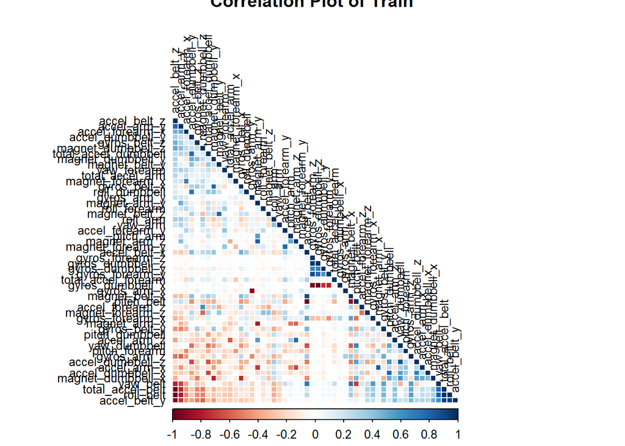

```r
myCor <- cor(Train[, -53])
corrplot(myCor,
         method = "color",
         type = "lower",
         add=FALSE,
         col=NULL,
         bg="white",
         title="Correlation Plot of Train",
         outline= TRUE,
         order = "FPC",
         tl.cex = 0.8,
         tl.col = "black")
```

## Further pre-processing Use Principal Component Analysis to remove correlated data. Default threshold is .8, we want more data columns to be utilized, so decided to use a threshold of .9.

```r
preProc <- preProcess(Train[, -53], method = "pca", thresh = 0.9)
PCA_Train <- predict(preProc, Train[, -53])
```

## Build Model

Use a random forest predictor as it is non-linear.  
Caution should be taken as it is prone to over-fitting.  
This step takes a bit of time to complete.

```r
myForest <- train(Train$classe ~ ., method = "rf", data = PCA_Train, trControl = trainControl(method = "cv", number = 4), importance = TRUE)
```

## Model Analysis

Produce a confusion matrix to review model, notice that the accuracy is 1.  
This is a very good accuracy, but concerned about over-fitting of Training data.

```r
pred_Forest <- predict(myForest, PCA_Train)
confusTrain <- confusionMatrix(Train$classe, pred_Forest)
confusTrain$table
```

```
##           Reference
## Prediction    A    B    C    D    E
##          A 3906    0    0    0    0
##          B    0 2658    0    0    0
##          C    0    0 2396    0    0
##          D    0    0    0 2252    0
##          E    0    0    0    0 2525
```

```r
accuracyTrain <- postResample(Train$classe, pred_Forest)
accuracyTrain[[1]]
```

```
## [1] 1
```

## Check model against test set

```r
PCA_Test <- predict(preProc, Test[, -53])
pred_Forest_Test <- predict(myForest, PCA_Test)
confusTest <- confusionMatrix(Test$classe, pred_Forest_Test)
confusTest$table
```

```
##           Reference
## Prediction    A    B    C    D    E
##          A 1661    6    6    1    0
##          B   37 1085   14    0    3
##          C    0   15  996   10    5
##          D    5    5   51  898    5
##          E    0    6    6    2 1068
```

```r
accuracyTest <- postResample(Test$classe, pred_Forest_Test)
accuracyTest[[1]]
```

```
## [1] 0.9699235
```

## Apply methods to Validation Set

Clean up Test set and run predictor on Validation

```r
myVal <- myVal[,(colSums(is.na(myVal)) == 0)]
myVal <- myVal[,-c(1:7)]
PCA_Val <- predict(preProc, myVal[, -53])
pred_val <- predict(myForest, PCA_Val)
pred_val
```

```
##  [1] B A A A A E D B A A B C B A E E A B B B
## Levels: A B C D E
```